# Homework - week 12

Amaliia Tsyndrina

## Merging tables

The goal of this week’s homework is to learn to merge tables without making mistakes and to practise data visualisation and interpretation.

#### TASK:

This week, let us revisit the COVID-19 data that we worked with in the beginning of the course. In the cloud you will find two files called *ger_cases.csv* and *ger_deaths.csv*. The files contain the *new cases* and *new deaths* recorded in Germany over time.

Task1: Merge the two tables **without** losing data. How many rows should your final table have?  
Task2: Now that you have everything in one table, calculate the *case fatality ratio* (recorded deaths / number cases) and plot it over time. If you plot the data directly after merging you will notice some strange spikes. Try to find out if they make sense and remove them if you think they are artefacts.

#### NOTES:

- Since we have a lot of data points it is advisable to convert the **date** column into the the data type `date` using the `as.Date()` function.

```r
library(dplyr)
```

```r
library(ggplot2)
library(tidyr)
deaths <- read.csv(file = "C:/Users/atsyndrina/Downloads/ger_deaths.csv")
cases <- read.csv(file = "C:/Users/atsyndrina/Downloads/ger_cases.csv")


new_table <- left_join(cases, deaths, by = "date")
dim(new_table)
```

```
## [1] 1022    3
```

```r
plot_table <- mutate(new_table, case_fatality_ratio = new_deaths_per_million / new_cases_per_million)
plot_table_1 <- mutate(plot_table, as.Date(date))
str(plot_table_1)
```

```
## 'data.frame':    1022 obs. of  5 variables:
##  $ date                  : chr  "2020-01-27" "2020-01-28" "2020-01-29" "2020-01-30" ...
##  $ new_cases_per_million : num  0.012 0.036 0 0 0.012 0.036 0.024 0.024 0 0 ...
##  $ new_deaths_per_million: num  NA NA NA NA NA NA NA NA NA NA ...
##  $ case_fatality_ratio   : num  NA NA NA NA NA NA NA NA NA NA ...
##  $ as.Date(date)         : Date, format: "2020-01-27" "2020-01-28" ...
```

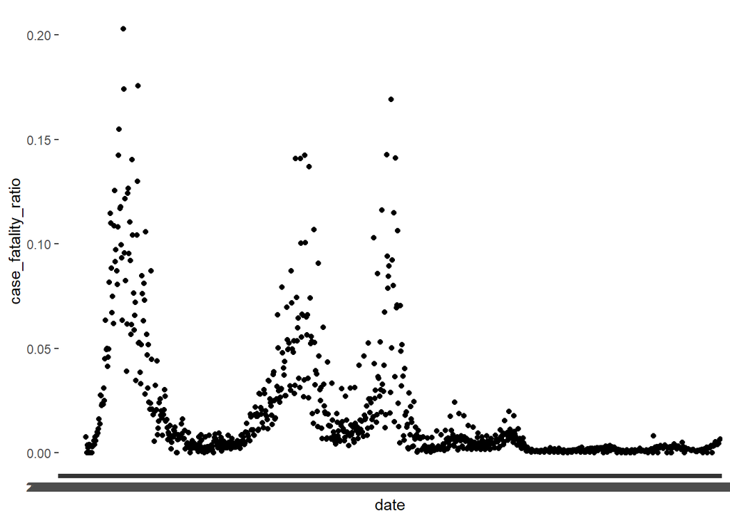

```r
plot_table_1 %>%
  ggplot(mapping  = aes(y = case_fatality_ratio, x = date)) +
  geom_point()
```